# This is Assignment 13 - Thienkim Le

## Requirement 3

Show the list of file types supported by the Matplotlib.

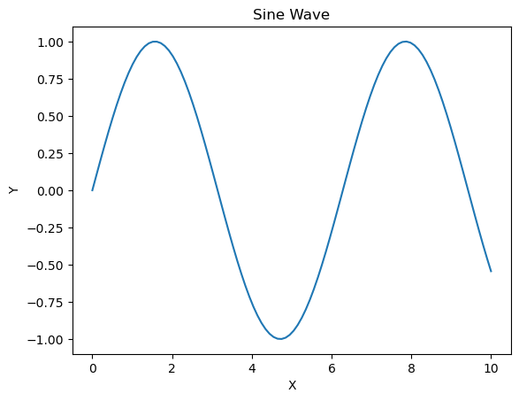

```python
# Saving as PNG
import matplotlib.pyplot as plt
import numpy as np

x = np.linspace(0, 10, 100)
y = np.sin(x)

plt.plot(x, y)
plt.title('Sine Wave')
plt.xlabel('X')
plt.ylabel('Y')

# Save as PNG
plt.savefig('sine_wave.png')
```

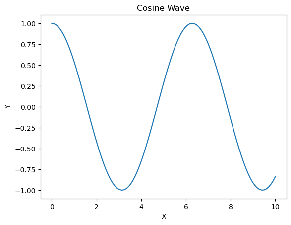

```python
# Saving as SVG
import matplotlib.pyplot as plt
import numpy as np

x = np.linspace(0, 10, 100)
y = np.cos(x)

plt.plot(x, y)
plt.title('Cosine Wave')
plt.xlabel('X')
plt.ylabel('Y')

# Save as SVG
plt.savefig('cosine_wave.svg', format='svg')
```

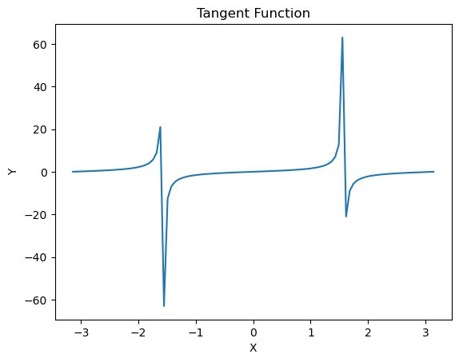

```python
# Saving as PDF
import matplotlib.pyplot as plt
import numpy as np

x = np.linspace(-np.pi, np.pi, 100)
y = np.tan(x)

plt.plot(x, y)
plt.title('Tangent Function')
plt.xlabel('X')
plt.ylabel('Y')

# Save as PDF
plt.savefig('tangent.pdf', format='pdf', bbox_inches='tight')
```

```
The PostScript backend does not support transparency; partially transparent artists will be rendered opaque.
```

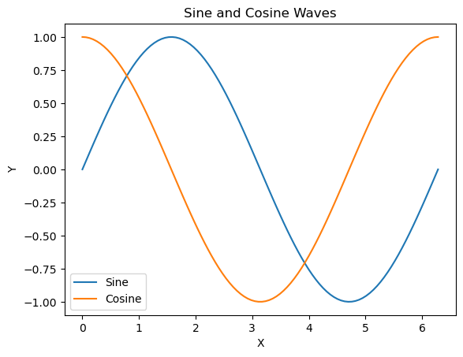

```python
# Saving as EPS
import matplotlib.pyplot as plt
import numpy as np

x = np.linspace(0, 2 * np.pi, 100)
y1 = np.sin(x)
y2 = np.cos(x)

plt.plot(x, y1, label='Sine')
plt.plot(x, y2, label='Cosine')
plt.title('Sine and Cosine Waves')
plt.xlabel('X')
plt.ylabel('Y')
plt.legend()

# Save as EPS
plt.savefig('sine_cosine.eps', format='eps', bbox_inches='tight')
```

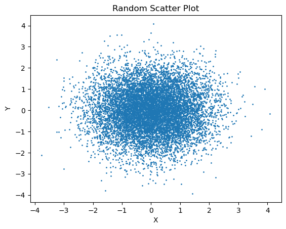

```python
# Saving as JPEG
import matplotlib.pyplot as plt
import numpy as np

x = np.random.randn(10000)
y = np.random.randn(10000)

plt.scatter(x, y, s=1)
plt.title('Random Scatter Plot')
plt.xlabel('X')
plt.ylabel('Y')

# Save as JPEG with quality=95
plt.savefig('scatter.jpg', format='jpg', dpi=300, bbox_inches='tight', pil_kwargs={'quality': 95})
```

## Requirement 4

Starting with:

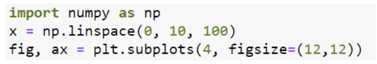

Use the Matplotlib object-oriented interface to display the sine, cosine, tangent, and arctangent of x, each in its own plot.

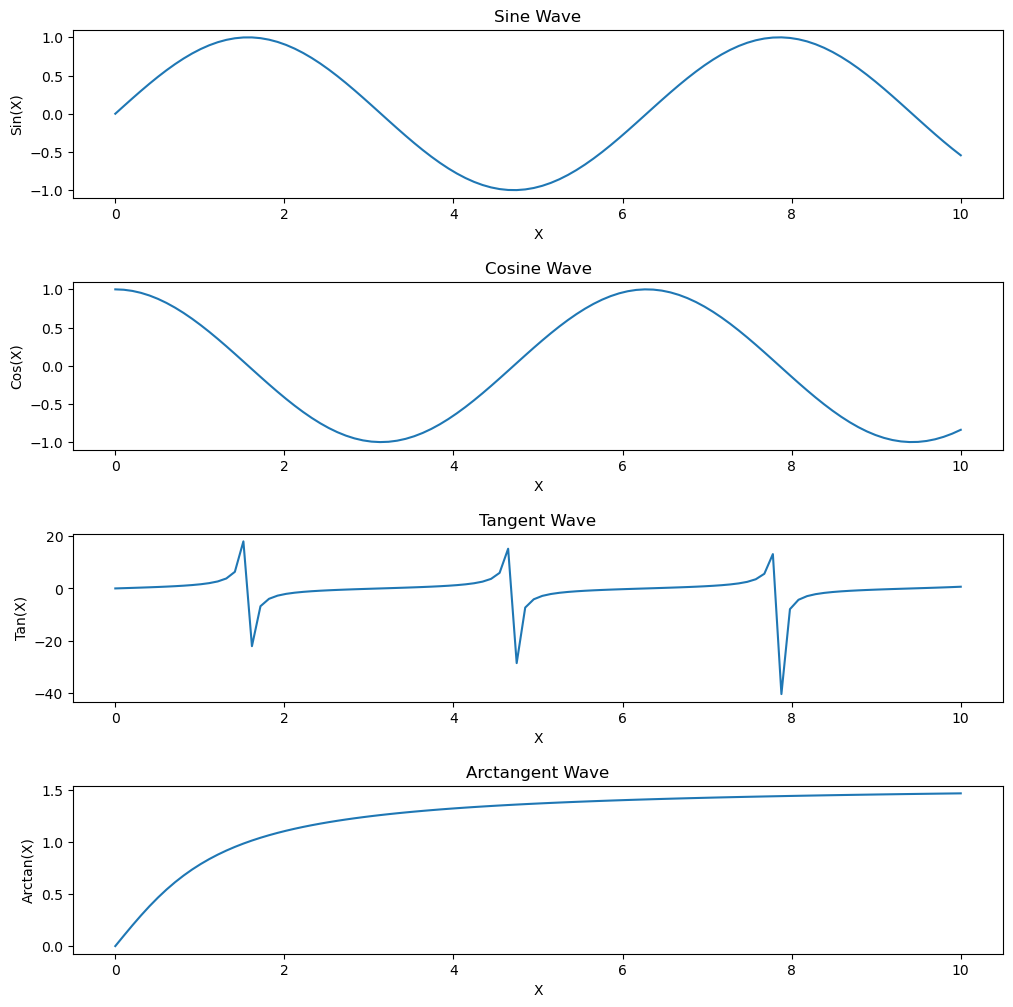

```python
import numpy as np
import matplotlib.pyplot as plt

x = np.linspace(0, 10, 100)
fig, ax = plt.subplots(4, figsize=(12, 12))

# Sine plot
ax[0].plot(x, np.sin(x))
ax[0].set_title('Sine Wave')
ax[0].set_xlabel('X')
ax[0].set_ylabel('Sin(X)')

# Cosine plot
ax[1].plot(x, np.cos(x))
ax[1].set_title('Cosine Wave')
ax[1].set_xlabel('X')
ax[1].set_ylabel('Cos(X)')

# Tangent plot
ax[2].plot(x, np.tan(x))
ax[2].set_title('Tangent Wave')
ax[2].set_xlabel('X')
ax[2].set_ylabel('Tan(X)')

# Arctangent plot
ax[3].plot(x, np.arctan(x))
ax[3].set_title('Arctangent Wave')
ax[3].set_xlabel('X')
ax[3].set_ylabel('Arctan(X)')

# Adjust spacing between subplots
plt.subplots_adjust(hspace=0.5)

plt.show()
```

## Requirement 5

Save the figures in the previous requirement to files and display the images from the files.

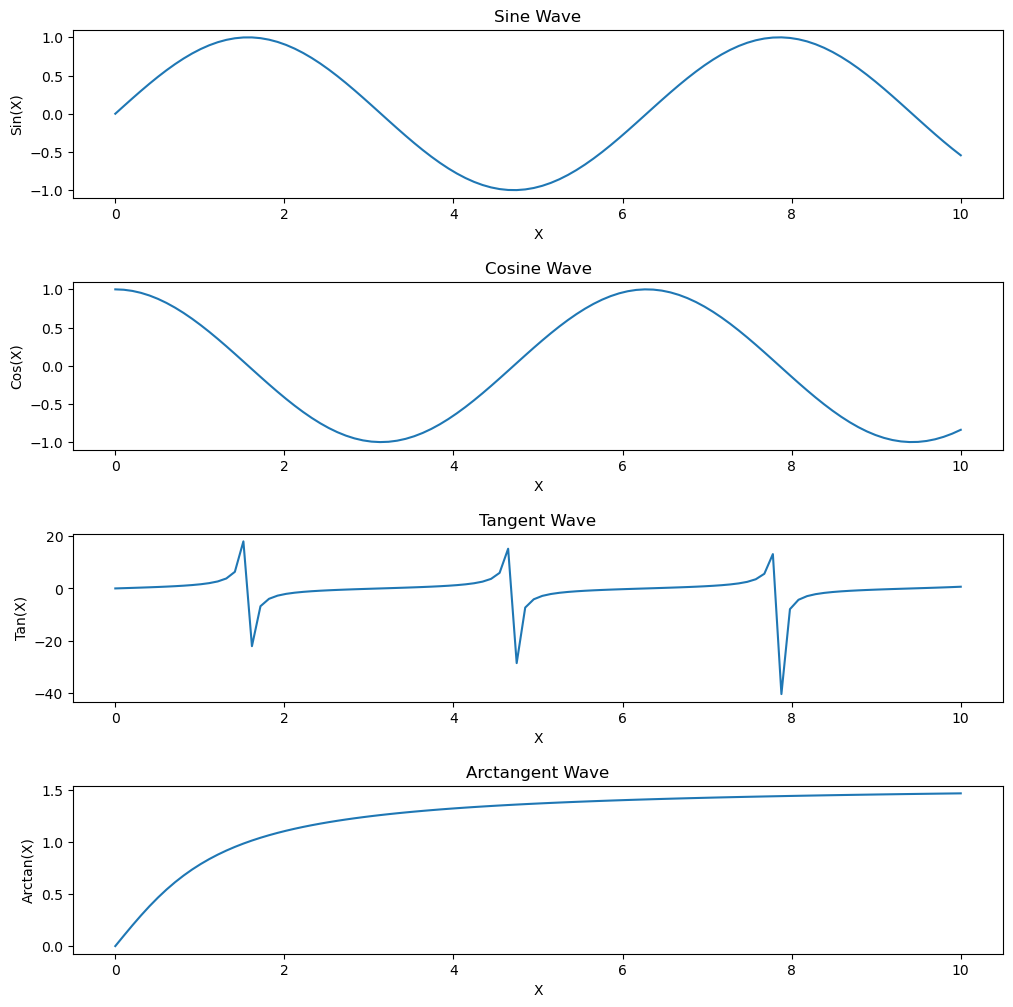

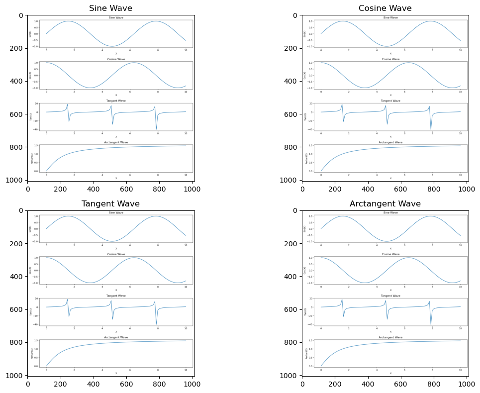

```python
import numpy as np
import matplotlib.pyplot as plt

x = np.linspace(0, 10, 100)
fig, ax = plt.subplots(4, figsize=(12, 12))

# Sine plot
ax[0].plot(x, np.sin(x))
ax[0].set_title('Sine Wave')
ax[0].set_xlabel('X')
ax[0].set_ylabel('Sin(X)')

# Cosine plot
ax[1].plot(x, np.cos(x))
ax[1].set_title('Cosine Wave')
ax[1].set_xlabel('X')
ax[1].set_ylabel('Cos(X)')

# Tangent plot
ax[2].plot(x, np.tan(x))
ax[2].set_title('Tangent Wave')
ax[2].set_xlabel('X')
ax[2].set_ylabel('Tan(X)')

# Arctangent plot
ax[3].plot(x, np.arctan(x))
ax[3].set_title('Arctangent Wave')
ax[3].set_xlabel('X')
ax[3].set_ylabel('Arctan(X)')

# Adjust spacing between subplots
plt.subplots_adjust(hspace=0.5)

# Save figures to files
plt.savefig('sine_wave.png', bbox_inches='tight')
plt.savefig('cosine_wave.png', bbox_inches='tight')
plt.savefig('tangent_wave.png', bbox_inches='tight')
plt.savefig('arctangent_wave.png', bbox_inches='tight')

# Display images from files
sine_img = plt.imread('sine_wave.png')
cosine_img = plt.imread('cosine_wave.png')
tangent_img = plt.imread('tangent_wave.png')
arctangent_img = plt.imread('arctangent_wave.png')

fig, ax = plt.subplots(2, 2, figsize=(12, 8))
ax[0, 0].imshow(sine_img)
ax[0, 0].set_title('Sine Wave')
ax[0, 1].imshow(cosine_img)
ax[0, 1].set_title('Cosine Wave')
ax[1, 0].imshow(tangent_img)
ax[1, 0].set_title('Tangent Wave')
ax[1, 1].imshow(arctangent_img)
ax[1, 1].set_title('Arctangent Wave')

plt.tight_layout()
plt.show()
```

## Requirement 6

Plot the sin() and cos() functions on the same graph.

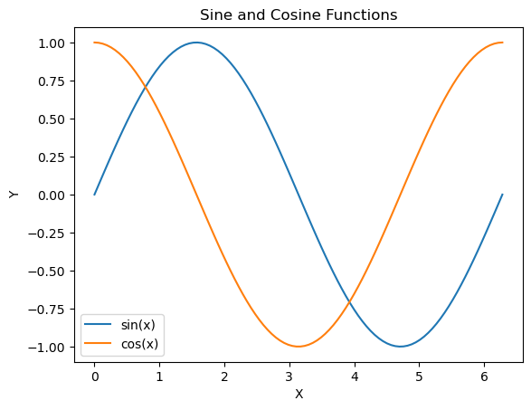

```python
import numpy as np
import matplotlib.pyplot as plt

# Create a NumPy array with evenly spaced values from 0 to 2*pi
x = np.linspace(0, 2*np.pi, 100)

# Calculate the sine and cosine values
y_sin = np.sin(x)
y_cos = np.cos(x)

# Create a figure and axis object
fig, ax = plt.subplots()

# Plot the sine and cosine curves
ax.plot(x, y_sin, label='sin(x)')
ax.plot(x, y_cos, label='cos(x)')

# Add labels and a legend
ax.set_xlabel('X')
ax.set_ylabel('Y')
ax.set_title('Sine and Cosine Functions')
ax.legend()

# Show the plot
plt.show()
```

## Requirement 7

Starting with:

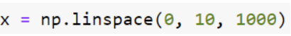

Plot the hyperbolic tangent (tanh()) function using six different color formats. Modify x slightly in each plot so the lines are distinct.

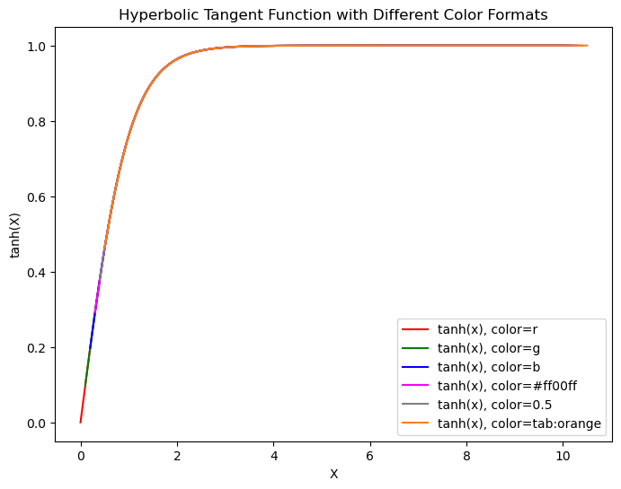

```python
import numpy as np
import matplotlib.pyplot as plt

# Create the base x array
x = np.linspace(0, 10, 1000)

# Define the color formats
color_formats = ['r', 'g', 'b', '#ff00ff', '0.5', 'tab:orange']

# Create a figure and axis object
fig, ax = plt.subplots(figsize=(8, 6))

# Plot the tanh function with different color formats
for i, color in enumerate(color_formats):
    x_shifted = x + i * 0.1  # Shift x slightly for each plot
    y = np.tanh(x_shifted)
    ax.plot(x_shifted, y, color=color, label=f'tanh(x), color={color}')

# Add labels, title, and legend
ax.set_xlabel('X')
ax.set_ylabel('tanh(X)')
ax.set_title('Hyperbolic Tangent Function with Different Color Formats')
ax.legend()

# Show the plot
plt.show()
```

## Requirement 8

Using the same x as above, plot the cosine (cos()) using 4 different color formats and 4 different line types. Modify x slightly in each plot so the lines are distinct.

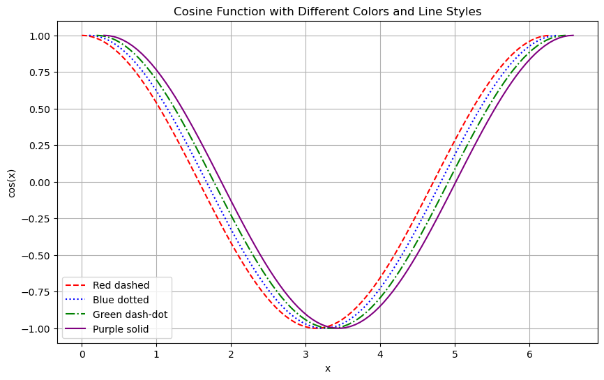

```python
import numpy as np
import matplotlib.pyplot as plt

x = np.linspace(0, 2*np.pi, 100)

# Plot cosine with different colors and line styles
plt.figure(figsize=(10, 6))

# Plot 1: Red dashed line
plt.plot(x, np.cos(x), color='red', linestyle='--', label='Red dashed')

# Plot 2: Blue dotted line
plt.plot(x + 0.1, np.cos(x), color='blue', linestyle=':', label='Blue dotted')

# Plot 3: Green dash-dot line
plt.plot(x + 0.2, np.cos(x), color='green', linestyle='-.', label='Green dash-dot')

# Plot 4: Purple solid line
plt.plot(x + 0.3, np.cos(x), color='purple', linestyle='-', label='Purple solid')

plt.xlabel('x')
plt.ylabel('cos(x)')
plt.title('Cosine Function with Different Colors and Line Styles')
plt.legend()
plt.grid(True)
plt.show()
```

## Requirement 9

Demonstrate limiting the x and y axes values in a plot.

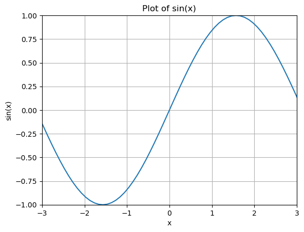

```python
import numpy as np
import matplotlib.pyplot as plt

# Generate some sample data
x = np.linspace(-5, 5, 100)
y = np.sin(x)

# Plot the data
plt.plot(x, y)
plt.xlabel('x')
plt.ylabel('sin(x)')
plt.title('Plot of sin(x)')

# Set limits for x and y axes
plt.xlim(-3, 3)  # Limiting x-axis from -3 to 3
plt.ylim(-1, 1)  # Limiting y-axis from -1 to 1

plt.grid(True)
plt.show()
```

## Requirement 10

Demonstrate a plot with an equal aspect ratio.

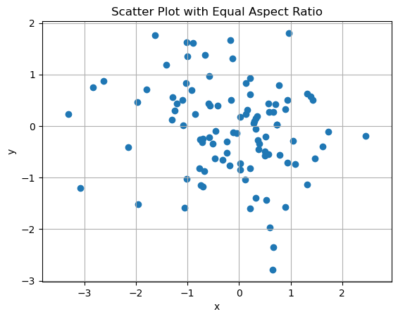

```python
import numpy as np
import matplotlib.pyplot as plt

# Generate some sample data
x = np.random.randn(100)
y = np.random.randn(100)

# Plot the data with equal aspect ratio
plt.scatter(x, y)
plt.xlabel('x')
plt.ylabel('y')
plt.title('Scatter Plot with Equal Aspect Ratio')

# Set equal aspect ratio
plt.axis('equal')

plt.grid(True)
plt.show()
```

## Requirement 11

Demonstrate the use of axis labels and a plot legend

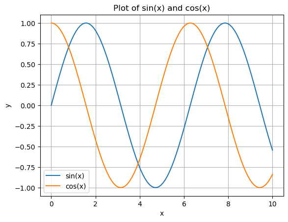

```python
import numpy as np
import matplotlib.pyplot as plt

# Generate some sample data
x = np.linspace(0, 10, 100)
y1 = np.sin(x)
y2 = np.cos(x)

# Plot the data
plt.plot(x, y1, label='sin(x)')
plt.plot(x, y2, label='cos(x)')
plt.xlabel('x')
plt.ylabel('y')
plt.title('Plot of sin(x) and cos(x)')
plt.legend()  # Show legend based on labels provided in the plot function calls

plt.grid(True)
plt.show()
```

## Requirement 12

Use RandomState() and plot() to demonstrate 11 different plot marker types. Also, display the markers in a legend

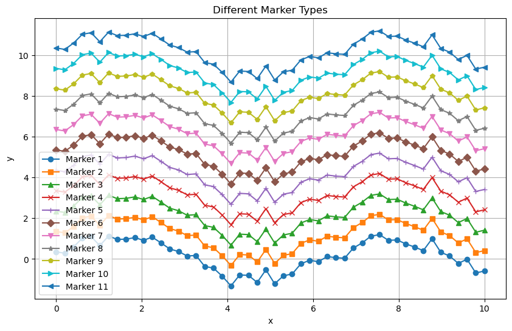

```python
import numpy as np
import matplotlib.pyplot as plt

# Set up random number generator with RandomState
rng = np.random.RandomState(0)

# Generate some sample data
x = np.linspace(0, 10, 50)
y = np.sin(x) + rng.randn(50) * 0.2  # Adding some random noise

# Define marker types
markers = ['o', 's', '^', 'x', '+', 'D', 'v', '*', 'p', '>', '<']

# Plot the data with different marker types
plt.figure(figsize=(10, 6))
for i, marker in enumerate(markers):
    plt.plot(x, y + i, marker=marker, label=f'Marker {i+1}')

plt.xlabel('x')
plt.ylabel('y')
plt.title('Different Marker Types')
plt.legend()

plt.grid(True)
plt.show()
```

## Requirement 13

Produce the following plot (diamonds are markers):

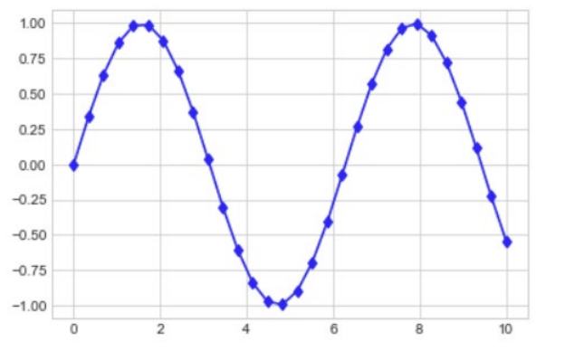

[figure not shown]

```python
import matplotlib.pyplot as plt

# Data for the plot
x = [0, 0.3, 1, 2, 3, 4, 5, 6, 7, 8, 9, 10]
y = [-0.1, 0.6, 0.9, 0.4, -0.6, -1.0, -0.6, 0.4, 0.9, 0.6, -0.1]

# Create the plot
plt.figure(figsize=(8, 6))
plt.plot(x, y, 'b-d')  # 'b-d' specifies blue line and diamond markers

# Add labels and title
plt.xlabel('X-axis')
plt.ylabel('Y-axis')
plt.title('Plot with Diamond Markers')

# Show the plot
plt.show()
```

## Requirement 14

Produce the following plot (notice the marker color and borders):

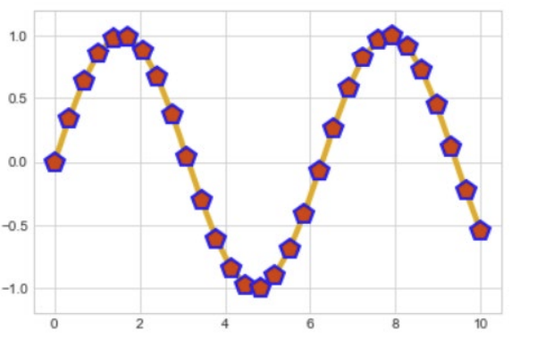

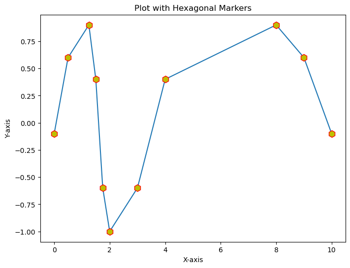

```python
import matplotlib.pyplot as plt
import numpy as np

# Data for the plot
x = [0, 0.5, 1.25, 1.5, 1.75, 2, 3, 4, 8, 9, 10]
y = [-0.1, 0.6, 0.9, 0.4, -0.6, -1.0, -0.6, 0.4, 0.9, 0.6, -0.1]

# Create the plot
plt.figure(figsize=(8, 6))
plt.plot(x, y, marker='h', markersize=10, markeredgecolor='r', markerfacecolor='y')

# Add labels and title
plt.xlabel('X-axis')
plt.ylabel('Y-axis')
plt.title('Plot with Hexagonal Markers')

# Show the plot
plt.show()
```

## Requirement 15

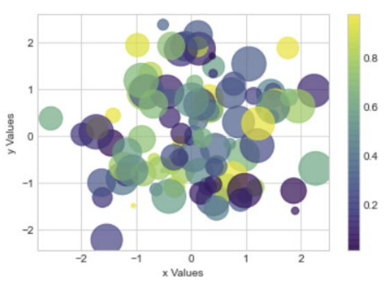

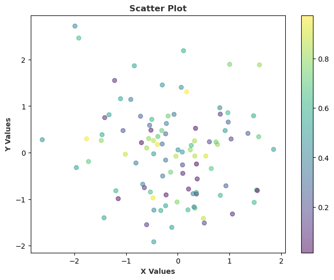

```python
import matplotlib.pyplot as plt
import numpy as np

# Generate random data
np.random.seed(42)
x = np.random.normal(0, 1, 100)
y = np.random.normal(0, 1, 100)
c = np.random.random(100)  # Provide data for colormapping

# Create the plot
fig, ax = plt.subplots(figsize=(8, 6))
scatter = ax.scatter(x, y, c=c, alpha=0.5, cmap='viridis')

# Add colorbar
cbar = fig.colorbar(scatter, ax=ax)
cbar.set_alpha(0.8)  # Set colorbar label transparency

# Add labels and title
ax.set_xlabel('X Values', fontweight='bold', alpha=0.8)  # Set x-label transparency
ax.set_ylabel('Y Values', fontweight='bold', alpha=0.8)  # Set y-label transparency
ax.set_title('Scatter Plot', fontweight='bold', alpha=0.8)  # Set title transparency

# Show the plot
plt.show()
```

## Requirement 16

Produce the following plot (use errorbar()). This page will be helpful:

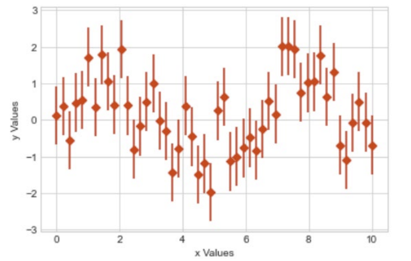

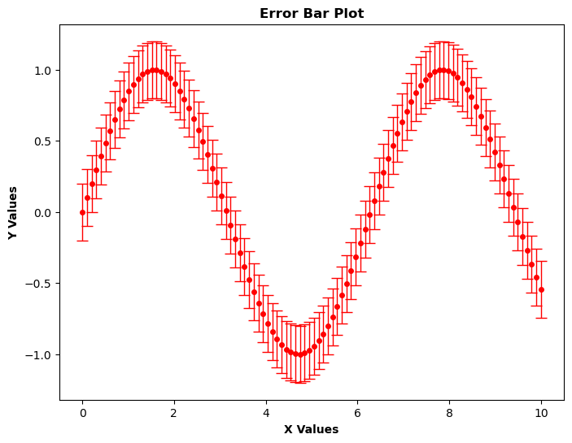

```python
import matplotlib.pyplot as plt
import numpy as np

# Generate data
x = np.linspace(0, 10, 100)
y = np.sin(x)
y_err = 0.2 * np.ones_like(y)  # Constant error value of 0.2

# Create the plot
fig, ax = plt.subplots(figsize=(8, 6))
ax.errorbar(x, y, yerr=y_err, fmt='ro', capsize=5, elinewidth=1, markeredgewidth=1, markersize=4)

# Add labels and title
ax.set_xlabel('X Values', fontweight='bold')
ax.set_ylabel('Y Values', fontweight='bold')
ax.set_title('Error Bar Plot', fontweight='bold')

# Show the plot
plt.show()
```

## Requirement 17

Produce the following plot (purple and orange). This page will be helpful:

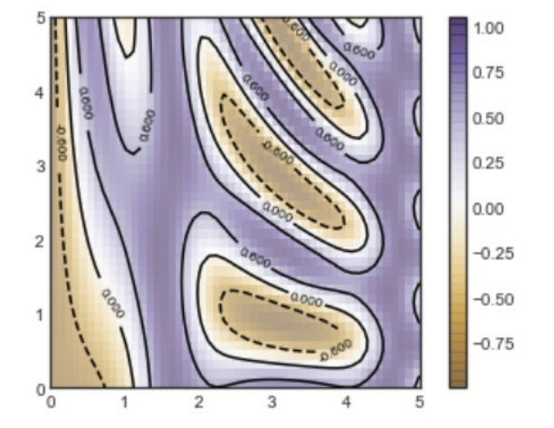

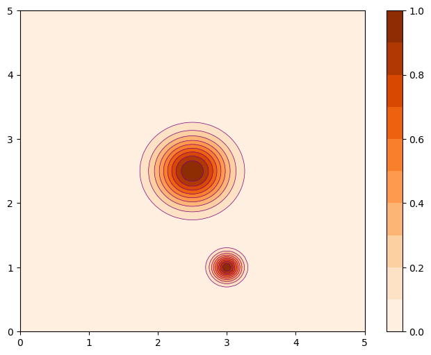

```python
import matplotlib.pyplot as plt
import numpy as np

# Generate data
x = np.linspace(0, 5, 100)
y = np.linspace(0, 5, 100)
X, Y = np.meshgrid(x, y)
Z = np.exp(-((X - 2.5)**2 + (Y - 2.5)**2) / 0.5**2) + np.exp(-((X - 3)**2 + (Y - 1)**2) / 0.2**2)

# Create the plot
fig, ax = plt.subplots(figsize=(8, 6))

# Plot filled contours (orange)
cont_filled = ax.contourf(X, Y, Z, levels=np.linspace(0, 1, 11), cmap='Oranges')

# Plot contour lines (purple)
cont_lines = ax.contour(X, Y, Z, levels=np.linspace(0, 1, 11), colors='purple', linewidths=0.5)

# Add a colorbar
cbar = fig.colorbar(cont_filled, ax=ax)

# Show the plot
plt.show()
```

## Requirement 18

Produce the following plot. This page will be helpful:

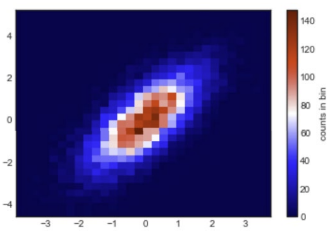

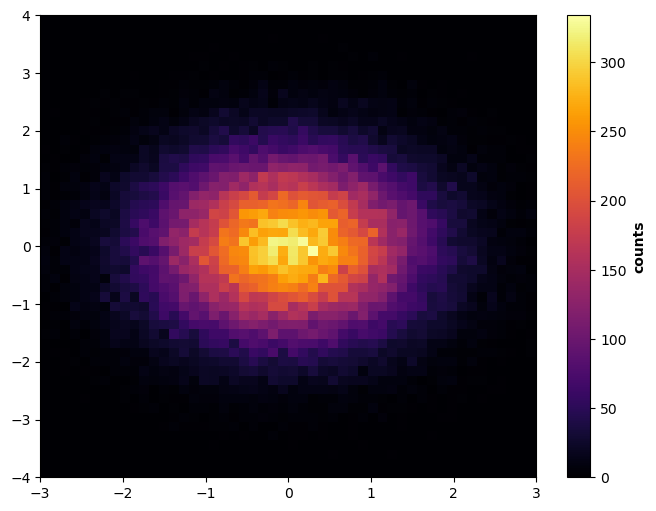

```python
import matplotlib.pyplot as plt
import numpy as np

# Generate data
x = np.random.randn(100000)
y = np.random.randn(100000)

# Create the plot
fig, ax = plt.subplots(figsize=(8, 6))

# Compute the 2D histogram
counts, xbins, ybins = np.histogram2d(x, y, bins=50, range=[[-3, 3], [-4, 4]])

# Plot the 2D histogram
im = ax.pcolormesh(xbins, ybins, counts.T, cmap='inferno')

# Add a colorbar
cbar = fig.colorbar(im, ax=ax)

# Set axis limits
ax.set_xlim(-3, 3)
ax.set_ylim(-4, 4)

# Adjust the colorbar label
cbar.set_label('counts', fontweight='bold')

# Show the plot
plt.show()
```

## Requirement 19

Produce the following plot (notice the color and legends).

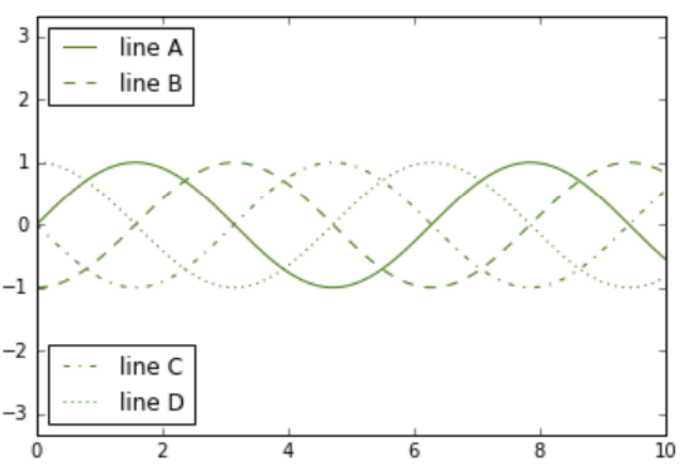

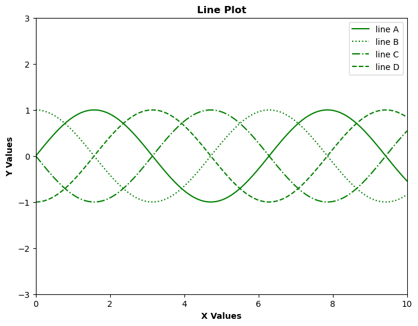

```python
import matplotlib.pyplot as plt
import numpy as np

# Generate data
x = np.linspace(0, 10, 100)
line_a = np.sin(x)
line_b = np.cos(x)
line_c = -np.sin(x)
line_d = -np.cos(x)

# Create the plot
fig, ax = plt.subplots(figsize=(8, 6))

# Plot the lines
ax.plot(x, line_a, color='green', label='line A')
ax.plot(x, line_b, color='green', linestyle=':', label='line B')
ax.plot(x, line_c, color='green', linestyle='-.', label='line C')
ax.plot(x, line_d, color='green', linestyle='--', label='line D')

# Add legend
ax.legend()

# Set axis limits
ax.set_xlim(0, 10)
ax.set_ylim(-3, 3)

# Add labels and title
ax.set_xlabel('X Values', fontweight='bold')
ax.set_ylabel('Y Values', fontweight='bold')
ax.set_title('Line Plot', fontweight='bold')

# Show the plot
plt.show()
```

## Requirement 20

Use markdown to include a statement at the end of assignment-13.ipynb explaining your experiences with Assignment 13. Make this authentic (minimum of 2-3 sentences)

Working on Assignment 13 was a great learning experience for me. It provided me with an opportunity to delve deeper into data visualization techniques using matplotlib in Python. I found it particularly rewarding to tackle the challenges presented in creating various types of plots and customizing them to meet specific requirements. Overall, it was a valuable exercise that further strengthened my skills in data visualization.